# Case Study 4.1 - Movies

# Note: If you close this notebook at any time, you will have to run all cells again upon re-opening it.

# ADVANCED PYTHON

As this is an advanced version, we don't include a lot of code here. If you get stuck on a particular part, feel free to also use the beginner version in `beginnner_python.ipynb` to help you out.

# Identification Information

```python
# YOUR NAME              = Jayhon Li
# YOUR MITX PRO USERNAME = jayhon626
# YOUR MITX PRO E-MAIL   = jayhon626@gmail.com
```

# Setup

Run these cells to install all the packages you need to complete the remainder of the case study. This may take a few minutes, so please be patient.

```python
!pip install surprise==0.1
```

```
twisted 18.7.0 requires PyHamcrest>=1.9.0, which is not installed.
You are using pip version 10.0.1, however version 18.1 is available.
```

Now, you must press **Kernel > Restart.** This allows the installation to take effect. Once you see the blue **Connected/Kernel ready** button in the top right, you are good to go.

# Import

```python
import pandas as pd
import matplotlib
from matplotlib import pyplot as pyp
from surprise import Dataset, SVD, NormalPredictor, BaselineOnly, KNNBasic, NMF
from surprise.model_selection import cross_validate, KFold, train_test_split
```

# Data

Use the [`**Dataset.load_builtin**`](http://surprise.readthedocs.io/en/stable/dataset.html#surprise.dataset.Dataset.load_builtin) function to load the data.

```python
# Your code here to load the data...
data = Dataset.load_builtin('ml-100k')
trainset, testset = train_test_split(data, test_size=.20)
```

We also want to get a sense of what the data looks like. Please create a histogram of all the ratings we have in the dataset.

```
80000
```

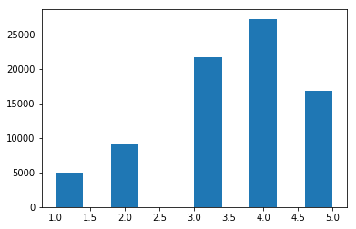

```python
# Your code here to create a ratings histogram...
ratings = []
for rating in trainset.all_ratings():
    ratings.append(rating[2])
pyp.hist(ratings)
len(ratings)
```

# QUESTION 1: DATA ANALYSIS

**Describe the dataset. How many ratings are in the dataset? How would you describe the distribution of ratings? Is there anything else we should observe? Make sure the histogram is visible in the notebook.**

# Model 1: Random

```python
# Create model using NormalPredictor() class
#trainset, testset = train_test_split(data, test_size = .20)
alg = NormalPredictor()
normal_model = alg.fit(trainset)
```

```python
# Train on data using cross-validation with k=5 folds, measuring the RMSE
cross_validate(normal_model, data, measures = ['RMSE'], cv = 5, verbose = True)
# See the cross_validate function that we have imported above
# http://surprise.readthedocs.io/en/stable/model_selection.html#surprise.model_selection.validation.cross_validate
```

```
Evaluating RMSE of algorithm NormalPredictor on 5 split(s).

                  Fold 1  Fold 2  Fold 3  Fold 4  Fold 5  Mean    Std
RMSE (testset)    1.5089  1.5254  1.5141  1.5360  1.5287  1.5226  0.0098
Fit time          0.10    0.12    0.12    0.12    0.11    0.11    0.01
Test time         0.16    0.10    0.15    0.10    0.10    0.12    0.03
```

```
{'test_rmse': array([1.50892855, 1.52536232, 1.51411306, 1.5359655 , 1.52867983]),
 'fit_time': (0.0951848030090332,
  0.11603665351867676,
  0.1161048412322998,
  0.11716008186340332,
  0.11456680297851562),
 'test_time': (0.16074705123901367,
  0.1037452220916748,
  0.1496880054473877,
  0.10271811485290527,
  0.10116100311279297)}
```